# no-show

Introduction

Project: Investigate a Dataset (Medical Appointments No_Shows)

This dataset collects information from medical appointments in Brazil and is focused on the question of whether or not patients show up for their appointment.

Summary of columns data:

PatientId : Identification of a patient

AppointmentID : Identification of each appointment

Gender : Male or Female

Age : How old is patient

Neighbourhood : Where the appointment takes place.

Scholarship : True of False . Please follow the link for understanding this variable https://en.wikipedia.org/wiki/Bolsa_Fam%C3%ADlia

Hipertension : True or False

Diabetes: True or False

Alcoholism : True or False

Handcap : True or False

SMS_received : 1 or more messages sent to the patient.

No-show : YES or NO

Libraries:

numpy,

pandas

matplotlib

seaborn

csv

```python
#importing libraries and dataset for the project
import pandas as pd
import numpy as np
import matplotlib.pyplot as plt
import seaborn as sns
%matplotlib inline
```

Question

What factors are important for us to know in order to predict if a patient will show up for their scheduled appointment?

Data Wranggling

Data Gathering

```python
df = pd.read_csv('/Users/user/datascience/udacity/KaggleV2-May-2016.csv')
```

Assessing

```python
#rows and colmns in dataset
df.shape
```

```
(110527, 14)
```

Lts check out the different columns with their respective datatypes

```python
df.info()
```

```
<class 'pandas.core.frame.DataFrame'>
RangeIndex: 110527 entries, 0 to 110526
Data columns (total 14 columns):
 #   Column          Non-Null Count   Dtype
---  ------          --------------   -----
 0   PatientId       110527 non-null  float64
 1   AppointmentID   110527 non-null  int64
 2   Gender          110527 non-null  object
 3   ScheduledDay    110527 non-null  object
 4   AppointmentDay  110527 non-null  object
 5   Age             110527 non-null  int64
 6   Neighbourhood   110527 non-null  object
 7   Scholarship     110527 non-null  int64
 8   Hipertension    110527 non-null  int64
 9   Diabetes        110527 non-null  int64
 10  Alcoholism      110527 non-null  int64
 11  Handcap         110527 non-null  int64
 12  SMS_received    110527 non-null  int64
 13  No-show         110527 non-null  object
dtypes: float64(1), int64(8), object(5)
memory usage: 11.8+ MB
```

From our dataset info above:

- datatype for patientid should be int not float -datatypes for appointment day and schedulledday should be Datetime not object(string) -there seems to be no missing values which is good
- columns headers not proper for my style.

```python
#Checking for any Null
df.apply(pd.isnull).sum().any()
```

```
False
```

```python
#understanding the dataset
df.describe()
```

|  | PatientId | AppointmentID | Age | Scholarship | Hipertension | Diabetes | Alcoholism | Handcap | SMS_received |
| --- | --- | --- | --- | --- | --- | --- | --- | --- | --- |
| count | 1.105270e+05 | 1.105270e+05 | 110527.000000 | 110527.000000 | 110527.000000 | 110527.000000 | 110527.000000 | 110527.000000 | 110527.000000 |
| mean | 1.474963e+14 | 5.675305e+06 | 37.088874 | 0.098266 | 0.197246 | 0.071865 | 0.030400 | 0.022248 | 0.321026 |
| std | 2.560949e+14 | 7.129575e+04 | 23.110205 | 0.297675 | 0.397921 | 0.258265 | 0.171686 | 0.161543 | 0.466873 |
| min | 3.921784e+04 | 5.030230e+06 | -1.000000 | 0.000000 | 0.000000 | 0.000000 | 0.000000 | 0.000000 | 0.000000 |
| 25% | 4.172614e+12 | 5.640286e+06 | 18.000000 | 0.000000 | 0.000000 | 0.000000 | 0.000000 | 0.000000 | 0.000000 |
| 50% | 3.173184e+13 | 5.680573e+06 | 37.000000 | 0.000000 | 0.000000 | 0.000000 | 0.000000 | 0.000000 | 0.000000 |
| 75% | 9.439172e+13 | 5.725524e+06 | 55.000000 | 0.000000 | 0.000000 | 0.000000 | 0.000000 | 0.000000 | 1.000000 |
| max | 9.999816e+14 | 5.790484e+06 | 115.000000 | 1.000000 | 1.000000 | 1.000000 | 1.000000 | 4.000000 | 1.000000 |

From our summary table above, we can see some abnormalities with the age column having a negative value. we will further lookat this later in our wrangling tour

```python
#Viewing the first three columns in the dataset
df.head(3)
```

|  | PatientId | AppointmentID | Gender | ScheduledDay | AppointmentDay | Age | Neighbourhood | Scholarship | Hipertension | Diabetes | Alcoholism | Handcap | SMS_received | No-show |
| --- | --- | --- | --- | --- | --- | --- | --- | --- | --- | --- | --- | --- | --- | --- |
| 0 | 2.987250e+13 | 5642903 | F | 2016-04-29T18:38:08Z | 2016-04-29T00:00:00Z | 62 | JARDIM DA PENHA | 0 | 1 | 0 | 0 | 0 | 0 | No |
| 1 | 5.589978e+14 | 5642503 | M | 2016-04-29T16:08:27Z | 2016-04-29T00:00:00Z | 56 | JARDIM DA PENHA | 0 | 0 | 0 | 0 | 0 | 0 | No |
| 2 | 4.262962e+12 | 5642549 | F | 2016-04-29T16:19:04Z | 2016-04-29T00:00:00Z | 62 | MATA DA PRAIA | 0 | 0 | 0 | 0 | 0 | 0 | No |

Cleaning

checking for missing values again

```python
df.apply(pd.isnull).sum()
```

```
PatientId         0
AppointmentID     0
Gender            0
ScheduledDay      0
AppointmentDay    0
Age               0
Neighbourhood     0
Scholarship       0
Hipertension      0
Diabetes          0
Alcoholism        0
Handcap           0
SMS_received      0
No-show           0
dtype: int64
```

From our code above, No missing values.

Coverting datatpes to appriopraite datetypes for the identified columns above

```python
#datatypes formatting for some date columns
df.AppointmentDay = pd.to_datetime(df.AppointmentDay)
df.ScheduledDay = pd.to_datetime(df.ScheduledDay)
```

patientid and appointmentid are just some randomly generated values by the system, hence will not be useful in our analysis. so we drop them

```python
#Dropping columns that are not helpful
df.drop(['PatientId', 'AppointmentID'], axis = 1, inplace= True)
```

Renaming dataset columns to a format we confortable with and easier for us to work with

```python
#Renaming the columns to a format conviniet for us to work with
df = df.rename(columns={'Hipertension': 'Hypertension', 'Handcap': 'Handicap', 'SMS_received': 'SMSReceived', 'No-show': 'NoShow'})
```

It might also be interesting to fine out the particular days of the week were patients may show or no show for thier apointmnts. Hence we need a columns for the different days of the week.

```python
#creating new coluns for days of the week
import datetime as dt
from time import strftime
df['Appointment_day_week'] = df['AppointmentDay'].dt.day_name()
df['Schuduled_day_week']   = df['ScheduledDay'].dt.day_name()
```

Its posible that long appoinments can cuased patients not to show up for their appoitments becuase they might havse forgotten. Hence it will be wise forus to know the number of days each appointment last.

```python
#Number of days a patient will have to wait
df['Waiting_time_days'] = df['AppointmentDay'] - df['ScheduledDay']
df['Waiting_time_days'] = df['Waiting_time_days'].dt.days
```

```python
#converting the No-show column for easy manipulation. This is more comfoorting fot me though.
show_map = {'Yes': 1, 'No': 0}
df['NoShow'] = df['NoShow'].map(show_map)
```

# checking the columns to be sure we are progressing

df.info()

We also need to check for duplicates in our dataset

```python
#checking for duplications
df.duplicated().any()
```

```
True
```

We have some duplicates rows, so lets fix the problem, by dropping the duplicates

```python
#Dropping the duplicates
df.drop_duplicates(keep='first', inplace=True)
```

```python
#Ensuring we are progressing with our data cleaning
df.duplicated().any()
```

```
False
```

Lets clean the age columns with strange data having -

```python
#Giving a special look at the age column
df.Age.describe()
```

```
count    109892.000000
mean         37.089506
std          23.121196
min          -1.000000
25%          18.000000
50%          37.000000
75%          55.000000
max         115.000000
Name: Age, dtype: float64
```

From the analysis on the age column, we can see a negetive value which in reality is not true. This might be an error during data entry. So we will clean this by cosidering only possitive values for ages

```python
#keeping only possive ages
df = df[df.Age >= 0]
```

```python
#Grouping the age column in to subgroups
cut_points = [0,5,12,18,35,60,100]
label_names = ["Infant","Child","Teenager","Young Adult","Adult","Senior"]
df["Age_categories"] = pd.cut(df["Age"],cut_points,labels=label_names)
```

Grouping our patients into those who can show and no-show wll also be a good idea.

```python
# 1==Yes, 0==N0
no_show = df[df.NoShow ==1] #patients show did not show up at all
show    =df[df.NoShow==0] # patients who showed up
```

```python
#chekcing to see our new df
df.head()
```

[output not shown]

Looking at the waiting_time_columns, we can see negative values. this is not normal. This might be as a result of data inconsistent: Appointment dates coming before schedulled dates. But the reality is the other way round.Lets see if we can fix this

```python
#Adjusting inconsistent data
df['AppointmentDay'] = np.where((df['AppointmentDay'] - df['ScheduledDay']).dt.days < 0, df['ScheduledDay'], df['AppointmentDay'])
```

```python
#Lets verify our changes
df.head()
```

[output not shown]

Part Three: Visualization, Exploratory Data Analysis

Attempting answer to our question above

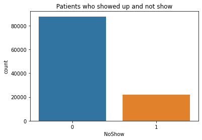

```python
#Visualizing those who show up and those who did not

ax = sns.countplot(x='NoShow' , data = df)
ax.set_title('Patients who showed up and not show')
plt.show()
```

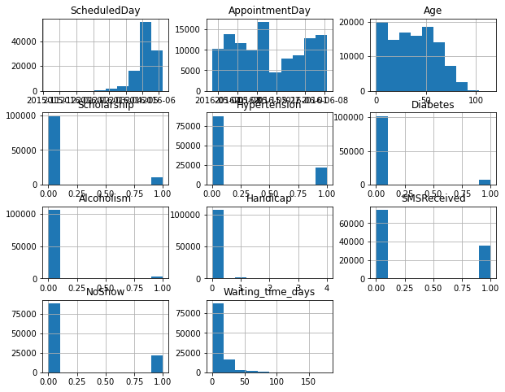

```python
df.hist(figsize=(10,8));
```

Since we will be needing sumarry statistics for patients who showed up for most of te columns, the function below will perform this for us for the identified coluns.

```python
def summery_stats(col):
    ratio = df[df.NoShow == 'No'].groupby([col]).size()/df.groupby([col]).size()
    ax = sns.barplot(x=ratio.index, y=ratio, palette="RdBu_r")
    ax.set_title("Show Percentage for {}".format(col))
    x_ticks_labels=['No {}'.format(col), '{}'.format(col)]
    ax.set_xticklabels(x_ticks_labels)
    return plt.show()
```

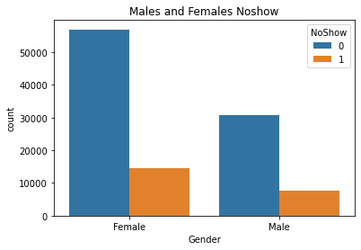

```python
#Ratio of males and females who showed up and those who did not
ax = sns.countplot(x=df.Gender, hue=df.NoShow, data = df)
ax.set_title('Males and Females Noshow')
x_ticks_labels=['Female', 'Male']
ax.set_xticklabels(x_ticks_labels)
plt.show()
```

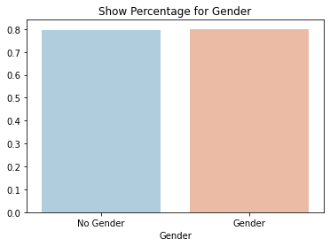

```python
summery_stats('Gender')
```

From the graph above, we can observe that out of the 88,000 patients that have turned up, around 57,000 of them are Females and 31,000 are Males. Of the 22,500 patients that haven't come for the visit around 15,000 are Females and 7,500 are Males

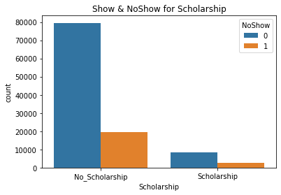

```python
#visualizing the scholarship column

ax = sns.countplot(x=df.Scholarship, hue=df.NoShow, data=df)
ax.set_title("Show & NoShow for Scholarship")
x_ticks_labels=['No_Scholarship', 'Scholarship']
ax.set_xticklabels(x_ticks_labels)
plt.show()
```

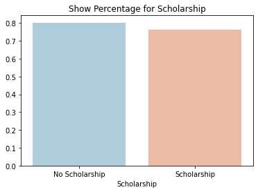

```python
summery_stats('Scholarship')
```

From the above visualization we can see that close to 100,000 patients without Scholarship and out of them around 80% showed up for their appointmnets. Out of the 10,500 patients with Scholarship around 75% of them do show up for their appointments. Hence, Scholarship feature could be a good determinant if a patient will turn up for the visit after an appointment.

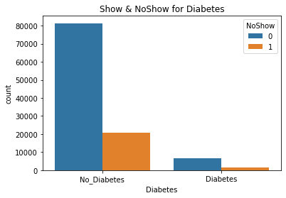

```python
#checking diabeties column
ax = sns.countplot(x=df.Diabetes, hue=df.NoShow, data=df)
ax.set_title("Show & NoShow for Diabetes")
x_ticks_labels=['No_Diabetes', 'Diabetes']
ax.set_xticklabels(x_ticks_labels)
plt.show()
```

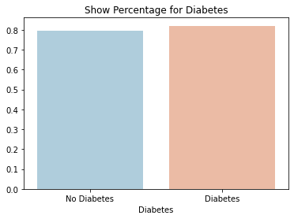

```python
summery_stats('Diabetes')
```

From the above visualization we can see that there are close to 102,000 patients without Diabetes and out of that number, 80% showed up for thier apppointments. Out of the 8,500 patients with Diabetes around 83% of them have come for the visit. Hence, Diabetes feature is another determinant to consider if a patient will turn up for the visit after an appointment.

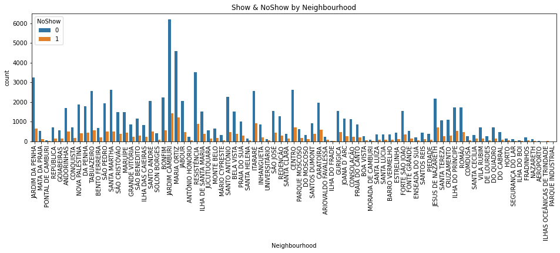

```python
plt.figure(figsize=(16,4))
plt.xticks(rotation=90)
ax = sns.countplot(x=df.Neighbourhood, hue=df.NoShow)
ax.set_title("Show & NoShow by Neighbourhood")
plt.show()
```

From the visualization above, in almost all neigbourhoods, more people show up for their appointmens

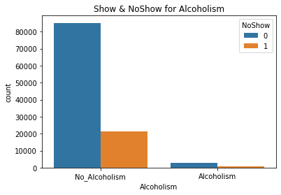

```python
ax = sns.countplot(x=df.Alcoholism, hue=df.NoShow, data=df)
ax.set_title("Show & NoShow for Alcoholism")
x_ticks_labels=['No_Alcoholism', 'Alcoholism']
ax.set_xticklabels(x_ticks_labels)
plt.show()
```

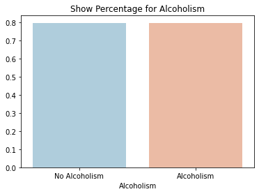

```python
summery_stats('Alcoholism')
```

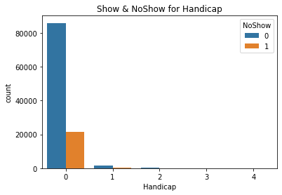

```python
ax = sns.countplot(x=df.Handicap, hue=df.NoShow, data=df)
ax.set_title("Show & NoShow for Handicap")
plt.show()
```

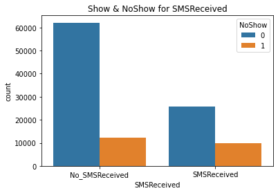

```python
ax = sns.countplot(x=df.SMSReceived, hue=df.NoShow, data=df)
ax.set_title("Show & NoShow for SMSReceived")
x_ticks_labels=['No_SMSReceived', 'SMSReceived']
ax.set_xticklabels(x_ticks_labels)
plt.show()
```

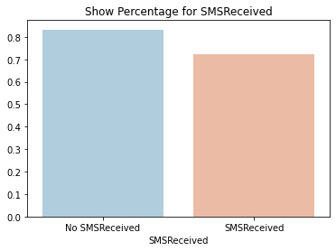

```python
summery_stats('SMSReceived')
```

From our visualization above, we can see that there are close to 75,000 patients who did not received SMS and out of them around 84% have honored their appointments. Out of the 35,500 patients who have received SMS around 72% of them did honor thier appointment. This feature loks strange to me becuase, how could people recieve sms and not come for appointments? what could be cost of this? Hence, it is thus clear that this feature will be a good determinant as to weather people will show or not show for thier apppointments

lets draw a boxplot for the Age feature to check it's distribution.

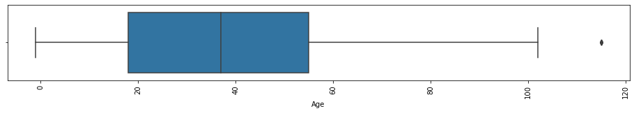

```python
plt.figure(figsize=(16,2))
plt.xticks(rotation=90)
_ = sns.boxplot(x=df.Age)
```

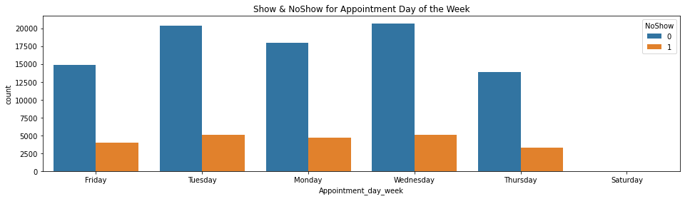

```python
plt.figure(figsize=(16,4))
ax = sns.countplot(x=df.Appointment_day_week, hue=df.NoShow)
ax.set_title("Show & NoShow for Appointment Day of the Week")
plt.show()
```

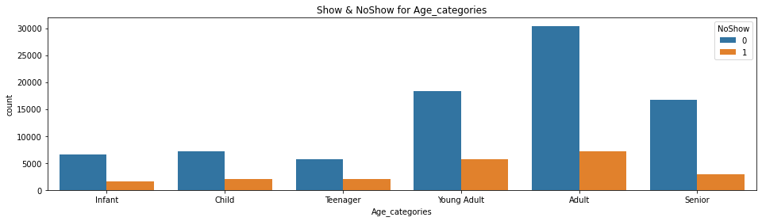

```python
plt.figure(figsize=(16,4))
ax = sns.countplot(x=df.Age_categories, hue=df.NoShow)
ax.set_title("Show & NoShow for Age_categories")
plt.show()
```

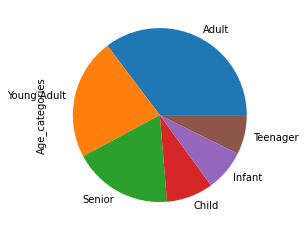

```python
df.Age_categories.value_counts().plot.pie();
```

Hence, the Age feature is also a very good determimant as to weather patients will show up for their appointment or not.

It is worth looking at the correlation between the Noshow columns with other columns

```python
df.corr()['NoShow'].sort_values()
```

```
Age                 -0.060886
Hypertension        -0.035992
Diabetes            -0.014527
Handicap            -0.006217
Alcoholism          -0.000588
Scholarship          0.029287
SMSReceived          0.128620
Waiting_time_days    0.179805
NoShow               1.000000
Name: NoShow, dtype: float64
```

Conclusions

Results:

Limitations:

-From our dataset, we can see that the AppointmentDay spans just over a month which means that we were given only a snapshot of complete data for that column. Though there are no null values in the data, making exact predictions and analysis on a snapshot data is difficult and the analysis might not make a representation of the whole data. The absence of no null values also make the data looks idle and not real world.

-Another very important thing that was missing from the data is the Time details in the AppointmentDay which would really help us a lot in predicting NoShow of a patient. As we have the time detail for ScheduledDay, we should have saved the similar thing in AppointmentDay also and not just normalize it.